# Дисперсионный анализ, часть 2

Линейные модели…

Валентина Домашкина, Вадим Хайтов, Анастасия Лянгузова, Наталья Арбузова, Юта Тамберг, Марина Варфоломеева

Кафедра Зоологии беспозвоночных, СПбГУ

## Многофакторный дисперсионный анализ

- Модель многофакторного дисперсионного анализа;
- Взаимодействие факторов;
- Несбалансированные данные, типы сумм квадратов;
- Многофакторный дисперсионный анализ в R;
- Дисперсионный анализ в матричном виде.

### Вы сможете

- Проводить многофакторный дисперсионный анализ и интерпретировать его результаты с учётом взаимодействия факторов.

# One Way ANOVA Update: Линейные контрасты

## Открываем данные

```r
library(DAAG)
data("cuckoos")
eggs <- cuckoos
head(eggs, 3)
```

```
  length breadth      species id
1   21.7    16.1 meadow.pipit 21
2   22.6    17.0 meadow.pipit 22
3   20.9    16.2 meadow.pipit 23
```

```r
colnames(eggs) <- c('len', 'br', 'sp', 'id')
```

## Изменим названия уровней фактора, чтобы было легче понять, о каких птицах речь

```r
levels(eggs$sp)
```

```
[1] "hedge.sparrow" "meadow.pipit"  "pied.wagtail"  "robin"
[5] "tree.pipit"    "wren"
```

```r
levels(eggs$sp) <- c("ЛесЗав", "ЛугКон", "БелТряс",
                     "Малин", "ЛесКон", "Крапив")
```

## Как понять, какие именно группы различаются

Дисперсионный анализ говорит нам только, есть ли влияние фактора, но не говорит, какие именно группы различаются.

Коэффициенты линейной модели в `summary(mod_treatment)` содержат лишь часть ответа — сравнение средних значений всех групп со средним на базовом уровне.

Если нас интересуют все возможные попарные сравнения, нужно сделать пост-хок тест.

## Пример: Post hoc Тест Тьюки

```r
library(multcomp)
mod_treatment <- lm(len ~ sp, data = eggs)
summary(glht(mod_treatment, linfct = mcp(sp = "Tukey")))
```

```
     Simultaneous Tests for General Linear Hypotheses

Multiple Comparisons of Means: Tukey Contrasts


Fit: lm(formula = len ~ sp, data = eggs)

Linear Hypotheses:
                      Estimate Std. Error t value Pr(>|t|)
ЛугКон - ЛесЗав == 0   -0.8210     0.2770   -2.96    0.041 *
БелТряс - ЛесЗав == 0  -0.2276     0.3364   -0.68    0.984
Малин - ЛесЗав == 0    -0.5580     0.3313   -1.68    0.538
ЛесКон - ЛесЗав == 0   -0.0343     0.3364   -0.10    1.000
Крапив - ЛесЗав == 0   -1.9943     0.3364   -5.93   <0.001 ***
БелТряс - ЛугКон == 0   0.5933     0.2699    2.20    0.241
Малин - ЛугКон == 0     0.2629     0.2635    1.00    0.915
ЛесКон - ЛугКон == 0    0.7867     0.2699    2.91    0.047 *
Крапив - ЛугКон == 0   -1.1733     0.2699   -4.35   <0.001 ***
Малин - БелТряс == 0   -0.3304     0.3253   -1.02    0.909
ЛесКон - БелТряс == 0   0.1933     0.3305    0.58    0.992
Крапив - БелТряс == 0  -1.7667     0.3305   -5.34   <0.001 ***
ЛесКон - Малин == 0     0.5238     0.3253    1.61    0.587
Крапив - Малин == 0    -1.4362     0.3253   -4.41   <0.001 ***
Крапив - ЛесКон == 0   -1.9600     0.3305   -5.93   <0.001 ***
---
Signif. codes:  0 '***' 0.001 '**' 0.01 '*' 0.05 '.' 0.1 ' ' 1
(Adjusted p values reported -- single-step method)
```

## Есть два способа понять, какие именно группы различаются

**Post hoc тесты**

- Сравниваются все возможные группы.
- Нет чётких заранее сформулированных гипотез.
- Делать можно, только если влияние соответствующего фактора оказалось значимым.

Этот способ мы уже обсуждали на предыдущей лекции.

**Линейные контрасты** (linear contrasts)

- Гипотезы о межгрупповых различиях тестируются при помощи комбинаций из коэффициентов линейной модели.
- Набор гипотез (и сравнений) **должен быть определён заранее**.
- Делать можно вне зависимости от результатов дисперсионного анализа.

Этот способ за рамками курса. Однако в некоторых отраслях это важно, мы обсудим лишь общую суть линейных контрастов.

## Контрасты vs post hoc: когда что использовать

Два способа ответить на «какие группы различаются»

| Критерий | Post hoc | Линейные контрасты |
| --- | --- | --- |
| Гипотезы | Все попарные (или все vs контроль) | Заданы заранее, до анализа |
| Зависят от значимости ANOVA | ДА — только для значимого фактора | Нет — можно тестировать всегда |
| Сколько вопросов | Много, сразу все | Мало, конкретные |
| Типичный вопрос | «Какие группы вообще различаются?» | «Конкретно эти две — различаются?» |

**Правило выбора**

- **Post hoc** — когда вопрос *исследовательский*: «что тут вообще происходит?»
- **Контрасты** — когда вопрос *сформулирован **заранее***: «яйца у ЛугКон крупнее, чем у БелТряс?»

Контрасты не заменяют post hoc и наоборот — это ответы на **разные вопросы**.

## Контрасты vs post hoc: пример на наших данных

**Post hoc (Тьюки)** — все пары сразу:

```r
library(multcomp)
mod_treatment <- lm(len ~ sp, data = eggs)
summary(glht(mod_treatment, linfct = mcp(sp = "Tukey")))
```

15 сравнений, читаем только значимые.

**Контрасты** — два заранее заданных вопроса:

```r
contr <- rbind(
  "БелТряс - ЛугКон" = c(0, -1, 0, 1, 0, 0),
  "ЛесЗав - ЛугКон"  = c(0, -1, 0, 0, 0, 1)
)
summary(glht(mod_treatment, linfct = contr))
```

## Применение линейных контрастов

Когда нам нужны только какие-то определённые группы сравнения, а не все группы со всеми сразу. Модель сравнения записывается в форме **матрицы контрастов**. Для начала разберемся со сравнением двух групп в модели, заданной параметризацией индикаторов.

Допустим, мы хотим сравнить лугового конька с белой трясогузкой. Возьмём лугового конька в качестве референсной группы. В таком случае можно оценить контраст для неё как: $L_1 = 1 * b_{ЛугКон} = 1 * b_{ЛугКон} + 0 * b_{БелТряс}$. Данное значение будет идентично интерсепту в R.

Контраст для второй группы сравнения можно записать как разница между средним значением в ней и референсным значением: $L_2 = 1 * b_{БелТряс} - 1 * b_{ЛугКон}$.

Таким образом, получаем матрицу следующего вида:

$$\begin{array}{cc} &
\begin{vmatrix}
1 & 0 \\
1 & -1
\end{vmatrix}\end{array}$$

## Линейные контрасты

Так же, как в случае записи модельной матрицы, такая полная запись несколько излишня, поскольку нас интересует только та часть матрицы, которая соответствует **сравнению** между двумя группами. Т.е. БелТряс — ЛугКон =

$$\begin{array}{cc} &
\begin{vmatrix}
1 & -1
\end{vmatrix}\end{array}$$

**НО!** В нашем датасете гораздо больше групп сравнения, и нас может интересовать большее количество групп. Например, хотим ещё сравнить размер лугового конька с лесной завирушкой.

Уравнение для данного случая можно записать следующим образом:
$$\textit{БелТряс} - \textit{ЛугКон} = 0$$
$$\textit{ЛесЗав} - \textit{ЛугКон} = 0$$

## Запись линейных контрастов текстом в R

```r
mod_treatment <- lm(len ~ sp, data = eggs)

library(multcomp)

eggs_contrtext <- glht(mod_treatment,
                       linfct = mcp(sp = c("БелТряс - ЛугКон = 0",
                                           "ЛесЗав - ЛугКон = 0")))

summary(eggs_contrtext)
```

```
     Simultaneous Tests for General Linear Hypotheses

Multiple Comparisons of Means: User-defined Contrasts


Fit: lm(formula = len ~ sp, data = eggs)

Linear Hypotheses:
                      Estimate Std. Error t value Pr(>|t|)
БелТряс - ЛугКон == 0    0.593      0.270    2.20   0.0580 .
ЛесЗав - ЛугКон == 0     0.821      0.277    2.96   0.0073 **
---
Signif. codes:  0 '***' 0.001 '**' 0.01 '*' 0.05 '.' 0.1 ' ' 1
(Adjusted p values reported -- single-step method)
```

## Запись матрицы контрастов с несколькими группами сравнения

В наших данных несколько видов птиц, сначала нужно записать уравнение с учётом каждого значения фактора.

Уравнение для длины яиц в гнёздах белой трясогузки:
$$Y_{БелТряс} = 1 * b_0 + 0 * b_{ЛугКон} + 0 * b_{Малин} + 1 * b_{БелТряс} + 0 * b_{ЛесКон} + 0 * b_{ЛесЗав}$$

в гнёздах лугового конька:
$$Y_{ЛугКон} = 1 * b_0 + 1 * b_{ЛугКон} + 0 * b_{Малин} + 0 * b_{БелТряс} + 0 * b_{ЛесКон} + 0 * b_{ЛесЗав}$$

в гнёздах лесной завирушки:
$$Y_{ЛесЗав} = 1 * b_0 + 0 * b_{ЛугКон} + 0 * b_{Малин} + 0 * b_{БелТряс} + 0 * b_{ЛесКон} + 1 * b_{ЛесЗав}$$

Для сравнения групп так же вычитаем члены одного уравнения из другого.

## Запись матрицы контрастов с несколькими группами сравнения

Например, для сравнения белой трясогузки и лугового конька.

$$БелТряс - ЛугКон = 0 * b_0 - 1 * b_{ЛугКон} + 0 * b_{Малин} + 1 * b_{БелТряс} + 0 * b_{ЛесКон} + 0 * b_{ЛесЗав}$$

Лесной завирушки и лугового конька:

$$ЛесЗав - ЛугКон = 0 * b_0 - 1 * b_{ЛугКон} + 0 * b_{Малин} + 0 * b_{БелТряс} + 0 * b_{ЛесКон} + 1 * b_{ЛесЗав}$$

## Запись матрицы контрастов в R

$$\begin{array}{cc} &
\begin{vmatrix}
0 & -1 & 0 & 1 & 0 & 0 \\
0 & -1 & 0 & 0 & 0 & 1
\end{vmatrix}\end{array}$$

Код будет выглядеть следующим образом:

```r
contr <- rbind("БелТряс - ЛугКон" = c(0, -1, 0, 1, 0, 0),
               "ЛесЗав - ЛугКон" = c(0, -1, 0, 0, 0, 1))
eggs_contrmat <- glht(mod_treatment, linfct = contr)
summary(eggs_contrmat)
```

[output not shown]

## Зачем для контраста нужна модель?

Контраст — это линейная комбинация **параметров модели** и **весов**:

$$L = c_1 b_1 + c_2 b_2 + \ldots + c_k b_k$$

Чтобы посчитать (L), нужно знать две вещи:

1. **Какие параметры** $b_1, \ldots, b_k$ есть в модели — то есть как задана **модельная матрица**.
2. **Какие веса** $c_1, \ldots, c_k$, т.е. элементы **матрицы контрастов**, соответствуют вашему вопросу.

Без первой части вторая бессмысленна: нельзя взвесить то, чего нет в модели.

## «Матрица контрастов»: два разных смысла

Две матрицы, которые называют «матрицей контрастов»

| Термин | Что это | Где используется |
| --- | --- | --- |
| Матрица линейных комбинаций (C) | Строки — контрасты, веса при параметрах модели | `glht(mod, linfct = C)` |
| Матрица кодировки фактора | Коды уровней, задающие параметры модели | `lm(..., contrasts = ...)` |

**Не путаем две разные матрицы**

Веса контраста — это **строка матрицы \(C\)**.

Но то, **какие параметры** стоят за этими весами, определяется **матрицей кодировки**, то есть **модельной матрицей**.

**Важно!** Один и тот же вектор весов для модельных матриц, заданных разными кодировками задает **разные гипотезы**.

## Зачем для контраста нужна модель?

### Модель задает остатки, описывает варьирование в системе и задает SE контраста

Стандартная ошибка контраста:

$$\text{SE}(L) = \sqrt{diag(\textbf{C} \times \textbf{VC} \times \textbf{C}')}$$

$\textbf{VC}$ берется **из модели**.

Другая модель (другие предикторы, другая параметризация, другая структура ошибок) → другая матрица ковариаций → другие SE → другие p-value для «того же» контраста.

## Три вопроса, на которые отвечает модель

1. **Какие параметры существуют?** — задает модельная матрица (кодировка факторов, наличие взаимодействий, свободный член).
2. **Что означает каждый параметр?** — отклонение от базового уровня (при параметризации перменных) или отклонение от среднего (при парамтеризации эффектов).
3. **Какова неопределённость параметров?** — $\textbf{VC}$ из модели; от неё зависит SE и p-value.

**Главное**

Линейный контраст **не существует сам по себе** — он всегда определён **относительно конкретной модели**. «Сравнить БелТряс и ЛугКон» — это вопрос, но чтобы получить p-value, нужно сказать: **в какой модели** и **какие веса** при её параметрах соответствуют этому вопросу.

Именно поэтому `glht(mod, linfct = ...)` требует **первым аргументом модель**: без неё `glht` не знает ни параметров, ни их ковариаций.

## Контрасты vs post hoc

**Внимание!** Результаты сравнений групп через линейные контрасты и через post hoc тесты могут быть разными!

- Разные гипотезы (контраст ≠ попарное сравнение)
- Разные поправки на множественность (post hoc платит за все пары, контраст — только за свои)
- Модель при этом одна, а вот вопросы и цена ошибки — разные.

**Контрасты мощнее**, но требуют дисциплины (гипотеза должна быть сформулирована до сравнения). Они дают более узкие доверительные интервалы и меньшие p-value именно потому, что тестируют меньше гипотез. Это законно только если гипотезы сформулированы **до просмотра данных**. Иначе вы фактически делаете неявный post-hoc-поиск и FWER (Family-Wise Error Rate) не контролируется.

# One Way ANOVA Update: параметризация модели

## Для кодирования дискретных факторов в R используются две параметризации

**Параметризация индикаторных переменных**

Так же известна как - dummy coding - treatment parametrisation - reference cell model

В R обозначается **contr.treatment**. С ней вы уже знакомы. Используется по умолчанию в R.

**Параметризация эффектов**

Так же известна как - effects coding - sum-to-zero parameterisation

В R обозначается **contr.sum**.

Это “классическая” параметризация для дисперсионного анализа. Нужна, если изначально предполагается, что факторы взаимодействуют и взаимодействия мы удалять не собираемся.

# Параметризация индикаторных переменных

## Переменные-индикаторы

Фрагмент модельной матрицы:

| sp | spЛугКон $x_1$ | spМалин $x_2$ | spБелТряс $x_3$ | spЛесКон $x_4$ | spЛесЗав $x_5$ |
| --- | --- | --- | --- | --- | --- |
| Крапив |  |  |  |  |  |
| ЛугКон |  |  |  |  |  |
| Малин |  |  |  |  |  |
| БелТряс |  |  |  |  |  |
| ЛесКон |  |  |  |  |  |
| ЛесЗав |  |  |  |  |  |

## Переменные-индикаторы

Фрагмент модельной матрицы:

| sp | spЛугКон $x_1$ | spМалин $x_2$ | spБелТряс $x_3$ | spЛесКон $x_4$ | spЛесЗав $x_5$ |
| --- | --- | --- | --- | --- | --- |
| Крапив | 0 | 0 | 0 | 0 | 0 |
| ЛугКон | 1 | 0 | 0 | 0 | 0 |
| Малин | 0 | 1 | 0 | 0 | 0 |
| БелТряс | 0 | 0 | 1 | 0 | 0 |
| ЛесКон | 0 | 0 | 0 | 1 | 0 |
| ЛесЗав | 0 | 0 | 0 | 0 | 1 |

Переменных-индикаторов всегда на одну меньше, чем число уровней фактора.

## Коэффициенты модели в параметризации индикаторов

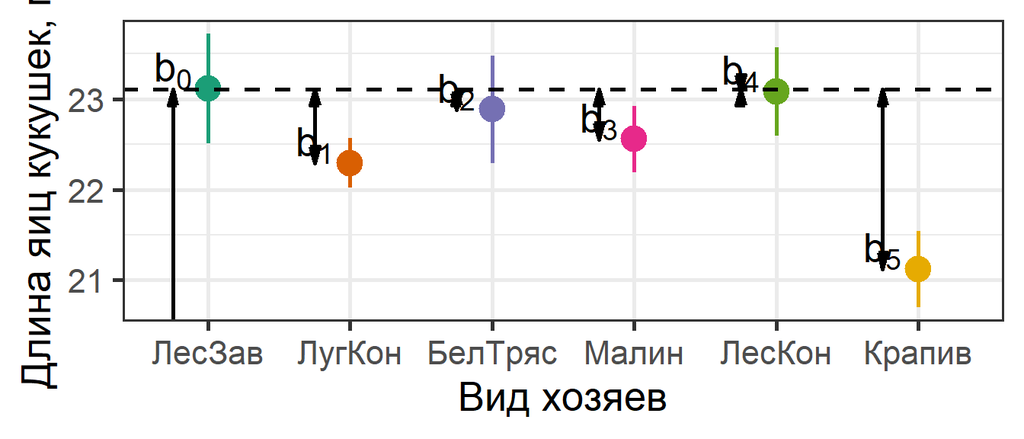

$$y_{i} = b_0 + b_1 x_{1i} + \ldots + b_5 x_{5i} + e_{i}$$

- $b_0$ — это среднее значение отклика для базового уровня фактора.
- $b_1, ..., b_5$ — это отклонения от базового уровня для средних с другими уровнями фактора.

## Подбор модели в параметризации индикаторов

```r
mod_treatment <- lm(len ~ sp, data = eggs)
round(coef(mod_treatment), 2)
```

```
(Intercept)    spЛугКон   spБелТряс     spМалин    spЛесКон
      23.11       -0.82       -0.23       -0.56       -0.03
   spКрапив
      -1.99
```

## Уравнение модели в параметризации индикаторов

Если их прибавить к базовому уровню, то получим предсказанные значения для других видов:

# Параметризация эффектов

## Другая точка отсчёта

В качестве референса можно использовать не базовый уровень, а **общее среднее значение**.

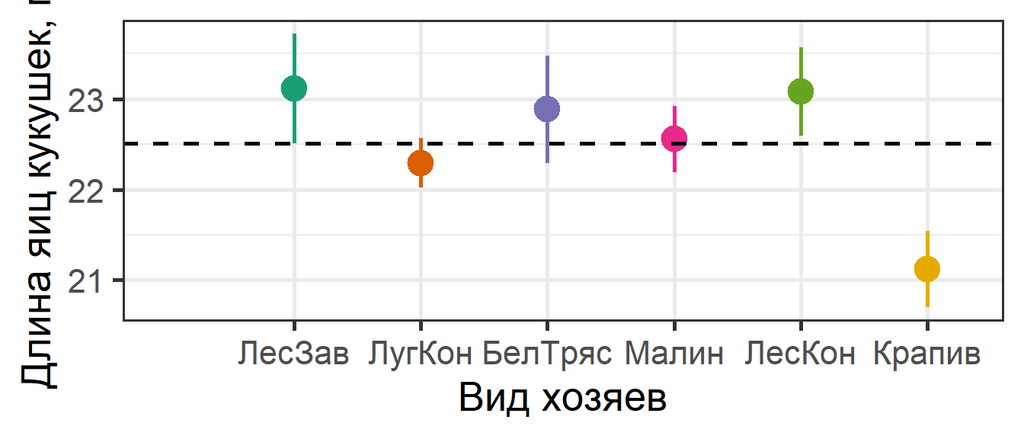

**Эффект фактора** — это величина, которая складывается из отклонений средних значений в каждой градации фактора от общей средней. Чем больше сумма квадратов отклонений, тем сильнее эффект фактора.

## Переменные-эффекты

Фрагмент модельной матрицы:

| sp | sp1 $x_1$ | sp2 $x_2$ | sp3 $x_3$ | sp4 $x_4$ | sp5 $x_5$ |
| --- | --- | --- | --- | --- | --- |
| Крапив |  |  |  |  |  |
| ЛугКон |  |  |  |  |  |
| Малин |  |  |  |  |  |
| БелТряс |  |  |  |  |  |
| ЛесКон |  |  |  |  |  |
| ЛесЗав |  |  |  |  |  |

Переменных-эффектов всегда на одну меньше, чем число уровней фактора.

Переменные закодированы при помощи -1, 0 и 1 (сумма кодов для возможных состояний одной переменной должна быть равна нулю).

Для последней группы все переменные-эффекты будут равны $-1$.

## Переменные-эффекты

Фрагмент модельной матрицы:

| sp | sp1 $x_1$ | sp2 $x_2$ | sp3 $x_3$ | sp4 $x_4$ | sp5 $x_5$ |
| --- | --- | --- | --- | --- | --- |
| Крапив | 1 | 0 | 0 | 0 | 0 |
| ЛугКон | 0 | 1 | 0 | 0 | 0 |
| Малин | 0 | 0 | 1 | 0 | 0 |
| БелТряс | 0 | 0 | 0 | 1 | 0 |
| ЛесКон | 0 | 0 | 0 | 0 | 1 |
| ЛесЗав | -1 | -1 | -1 | -1 | -1 |

Переменных-эффектов всегда на одну меньше, чем число уровней фактора.

Переменные закодированы при помощи -1, 0 и 1 (сумма кодов для возможных состояний одной переменной равна нулю).

Для последней группы все переменные-эффекты будут равны $-1$.

## Коэффициенты модели в параметризации эффектов

Фрагмент модельной матрицы:

| sp | sp1 $x_1$ | sp2 $x_2$ | sp3 $x_3$ | sp4 $x_4$ | sp5 $x_5$ |
| --- | --- | --- | --- | --- | --- |
| Крапив | 1 | 0 | 0 | 0 | 0 |
| ЛугКон | 0 | 1 | 0 | 0 | 0 |
| Малин | 0 | 0 | 1 | 0 | 0 |
| БелТряс | 0 | 0 | 0 | 1 | 0 |
| ЛесКон | 0 | 0 | 0 | 0 | 1 |
| ЛесЗав | -1 | -1 | -1 | -1 | -1 |

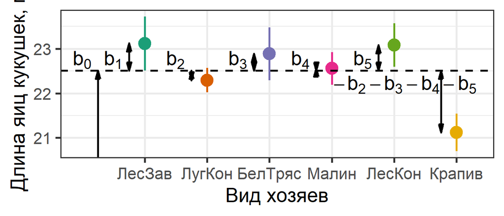

$$y_{i} = b_0 + b_1 x_{1i} + \ldots + b_5 x_{5i} + e_{i}$$

- $b_0$ — это общее среднее значение отклика.
- $b_1, ..., b_5$ — это отклонения от общего среднего для средних с другими уровнями фактора, кроме последнего.
- для последнего уровня фактора отклонения от общего среднего — это коэффициенты $b_1, ..., b_5$, взятые с противоположным знаком.

## Подбор модели в параметризации эффектов

```r
mod_sum <- lm(len ~ sp, data = eggs, contrasts = list(sp = contr.sum))
round(coef(mod_sum), 2)
```

```
(Intercept)         sp1         sp2         sp3         sp4
      22.51        0.61       -0.22        0.38        0.05
        sp5
       0.57
```

Коэффициенты моделей в разных параметризациях будут разными, но предсказания будут совершенно одинаковыми.